# MATH 3070 Lab Project 7

Kanishka Ragula

September 29, 2016

*Remember: I expect to see commentary either in the text, in the code with comments created using `#`, or (preferably) both! **Failing to do so may result in lost points!***

## Problem 1 (Verzani problem 5.6)

*For the `batting` (**UsingR**) data set, make parallel boxplots of the batting average (`H/AB`) for each team. Which team had the greatest median average? (Use **lattice** functions for this problem.)*

```r
library(UsingR)
```

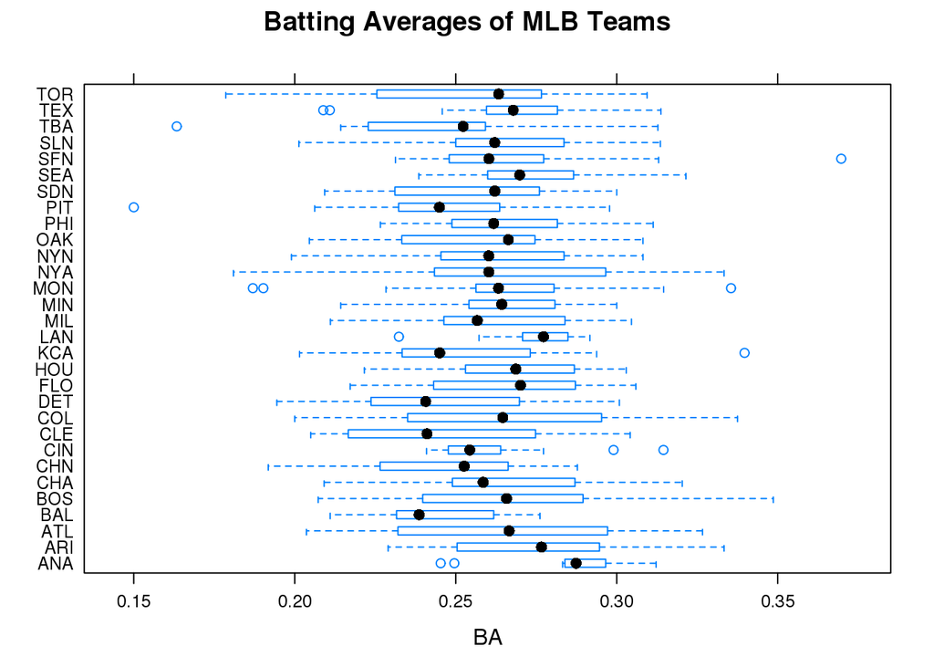

```r
library(lattice)
# Import libraries
attach(batting)
# attach batting to program
BA = H/AB
# Create new vector for batting
newbatting = cbind(batting, BA)
# Create new dataset
bwplot(teamID ~ BA, data = newbatting, main = "Batting Averages of MLB Teams")
```

```r
# Create the boxplot ANA has the greatest median average
```

## Problem 2 (Verzani problem 5.7)

*For the `mtcars` data set, produce graphics of the following using **ggplot2**:*

1. *Boxplots for miles per gallon (`mpg`) for groups defined by the number of gears (`gear`).*

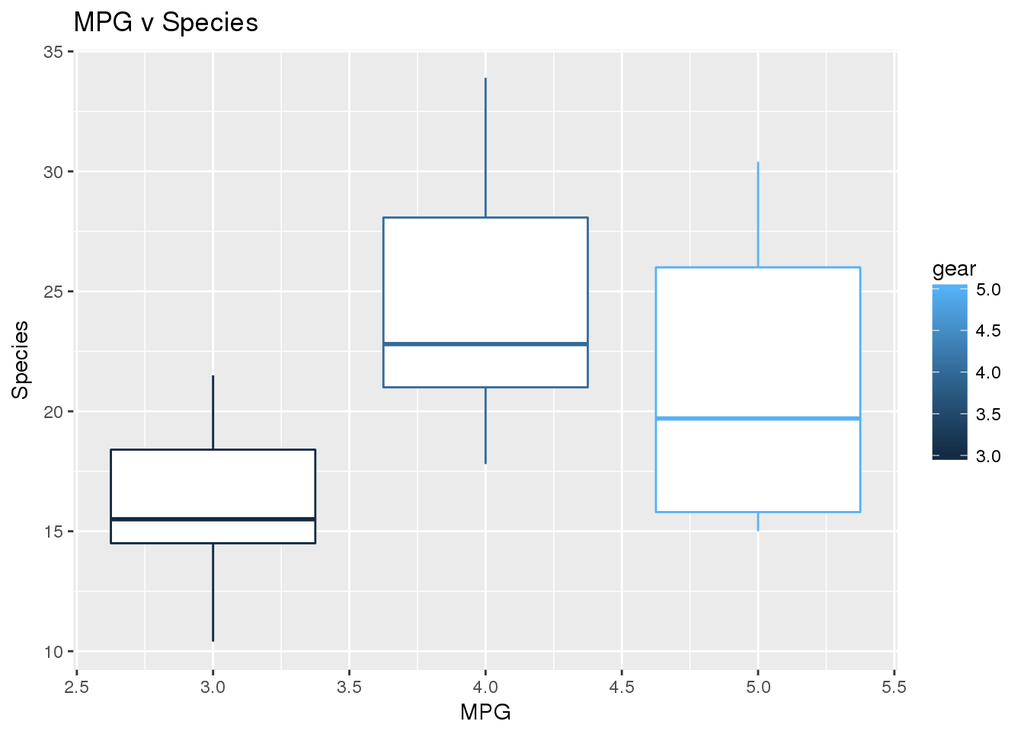

```r
library(ggplot2)
mpggear = ggplot(mtcars, aes (group = gear, y=mpg, x=gear, color = gear)) + #Break by gear
  xlab("MPG") +  #Label X
  ylab("Species") + #Label Y
  ggtitle("MPG v Species") + #Title
  geom_boxplot() #make a boxplot
mpggear
```

```r
# Plot the boxplot with data mtcars and title
```

2. *A scatterplot of `mpg` modeled by horsepower (`hp`). Create facets by the number of cylinders (`cyl`) and `gear`.*

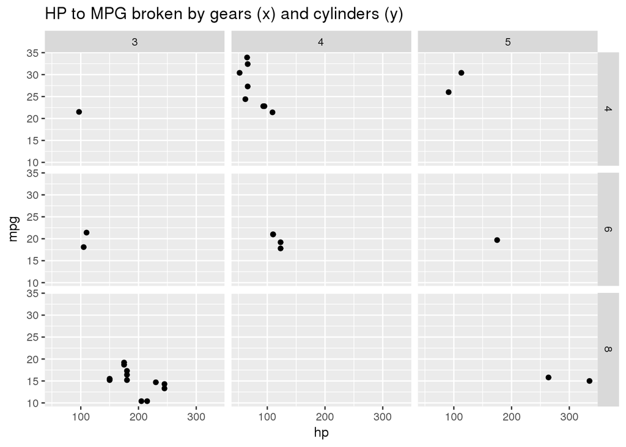

```r
mpghp = ggplot(mtcars, aes(x = hp, y= mpg)) + #Set up general ggplot
  geom_point() + #Scatterplot
  facet_grid(cyl~gear) + #Make a grid by cylinder and gear
  ggtitle("HP to MPG broken by gears (x) and cylinders (y)") #add title
mpghp #display
```